# Calculating Breast Cancer PGS for Yiwey Shieh

Peter Fiorica

2025-11-14

# Introduction

On November 13 2025, Song Yao, Christine Ambrosone, and I received an email from Larry Kushi (Subject: RE: EXTERNAL: Re: Pathways collaboration) requesting that we share the following PGS with Yiwey Shieh.

- PGS000004
- PGS000007
- PGS000015
- PGS000332

And *PGP000088* from Zhang et al Nat Genet (2020).

The above 4 are already calculated. I now need to calculate the last one PGS for the Pathways samples. Just like I did for the CVD project, I will uses PGCS_CALC

```
nextflow run pgscatalog/pgsc_calc \
    -profile singularity \
    --input /projects/rpci/songyao/pnfioric/pgs_calc/pathways_samplesheet2.csv --target_build GRCh37 \
    --pgs_id PGS000212, PGS000213, PGS000214, PGS000215, PGS000216 \
    --run_ancestry /projects/rpci/songyao/pnfioric/pgs_calc/pgsc_HGDP+1kGP_v1.tar.zst \
    --n_popcomp 5 -c /projects/rpci/songyao/pnfioric/pgs_calc/default_hpc.config --max_cpus 8
```

The above code executed with the `02_call_pgsc_calc.sh` script did not run properly since it appears that only 2/3 of the PGS SNPs intersect with the genotypes. Last time, this was because of the ancestry execution process where it only includes the SNPs that intersect with 1000G and HGDP.

[output not shown]

Once again when I execute the code:

```
nextflow run pgscatalog/pgsc_calc \
    -profile singularity \
    --input /projects/rpci/songyao/pnfioric/pgs_calc/pathways_samplesheet2.csv --target_build GRCh37 \
    --pgs_id  PGS000212,PGS000213,PGS000214,PGS000215,PGS000216 \
#    --run_ancestry /projects/rpci/songyao/pnfioric/pgs_calc/pgsc_HGDP+1kGP_v1.tar.zst \
    --outdir /projects/rpci/songyao/pnfioric/pgs_calc/breast_cancer_pgs/results/ \
#    --n_popcomp 5 \
    -c /projects/rpci/songyao/pnfioric/pgs_calc/default_hpc.config --max_cpus 8
```

# Switching things up

Ultimately, I decided to return to the older version of calculating the PGS manually. While PGSC_CALC had the advantages of scalability. It is not the easiest to troubleshoot. As a result, I decided to calculate the PGS using the original code. This process is described at https://github.com/pfiorica/WCHS_BrCa_PGS.

I work through the scripts numbered with `03_*` to `05_*`.

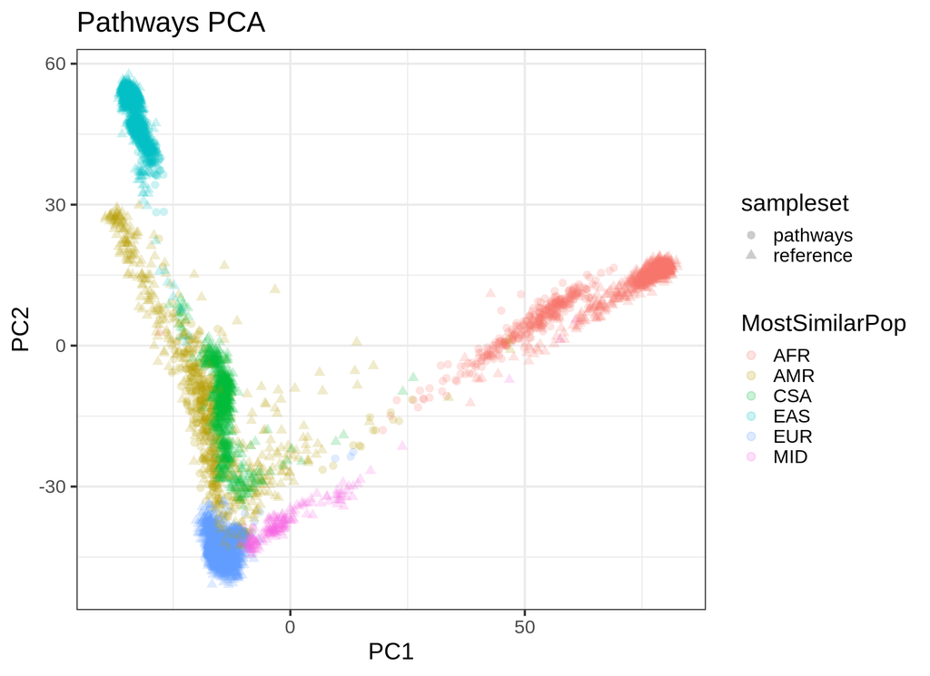

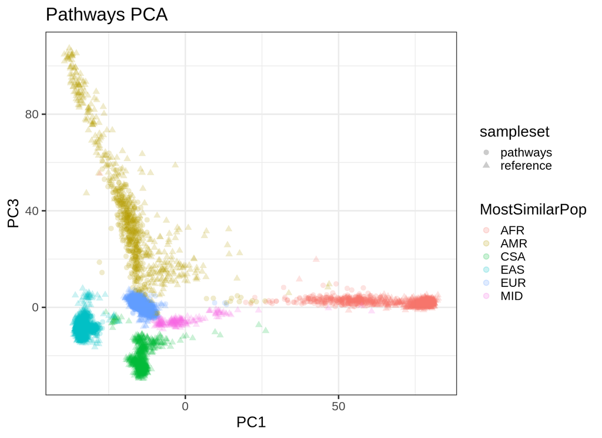

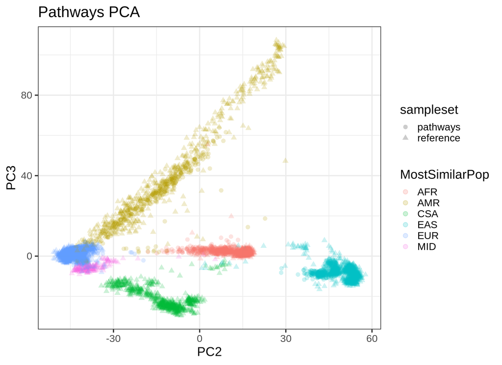

# Unnormalized

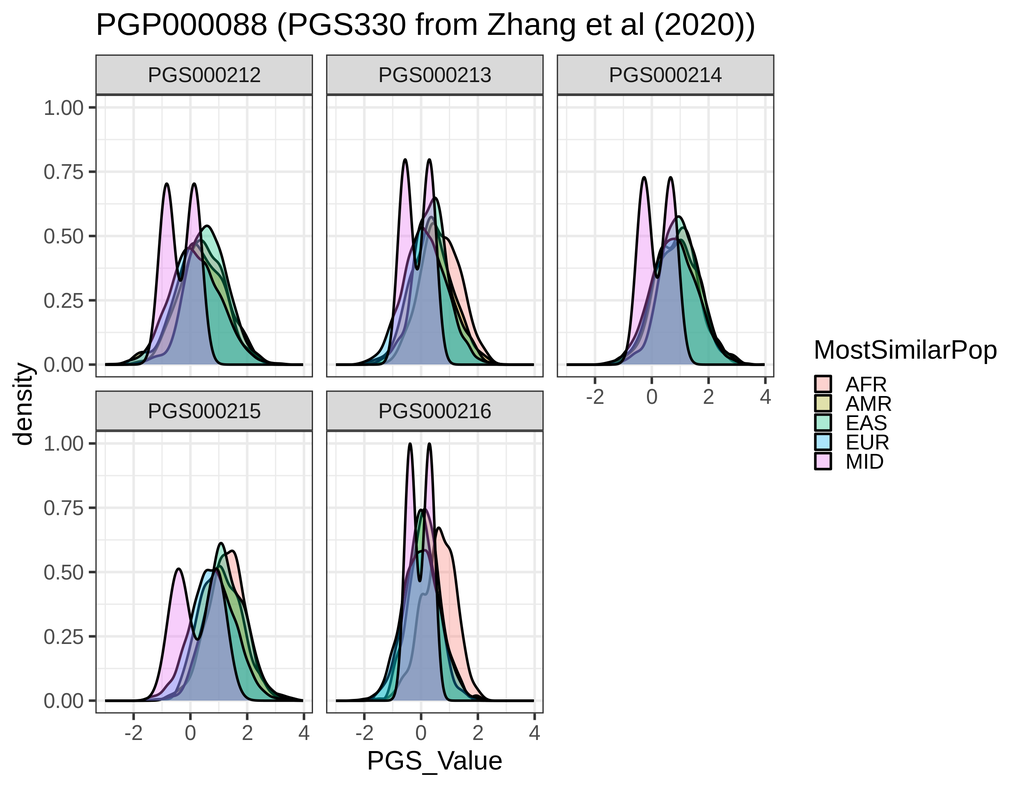

# Normalization

```r
pgs_cols <- grep("^PGS", names(pgs_results_sim), value = TRUE)

pgs_results_sim[, (pgs_cols) := lapply(.SD, function(x) (x - mean(x, na.rm=TRUE)) / sd(x, na.rm=TRUE)),
   by = MostSimilarPop,
   .SDcols = pgs_cols]

pgs_results_sim_longer_norm <- melt(
  pgs_results_sim,
  id.vars = c("samples", "MostSimilarPop"),
  measure.vars = patterns("^PGS"),
  variable.name = "PGS_ID",
  value.name = "PGS_Value"
)
```

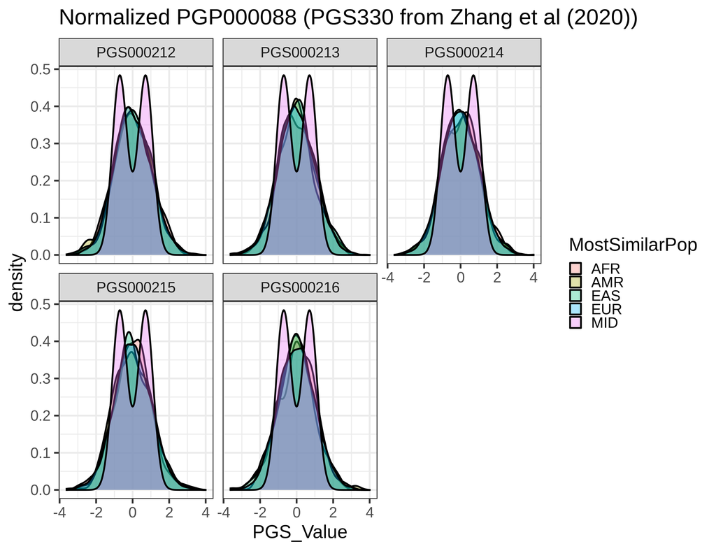

```r
pgs_results_sim_norm_to_write <- pgs_results_sim %>% select(samples:PGS000216, MostSimilarPop)
write.csv(pgs_results_sim_norm_to_write, "/projects/rpci/songyao/pnfioric/pgs_calc/breast_cancer_pgs/Pathways_330_PGS_Normalized.csv")
```